# Homework No 4

UTRGV School of Mathematical and Statistical Sciences

STAT 3301 Applied Statistics

Samuel Lee

> **Objective:** Use R studio to solve problems involving continuous random variables and applications to Normal Distributions.

Use R to solve the following problems.

#### Problem 1

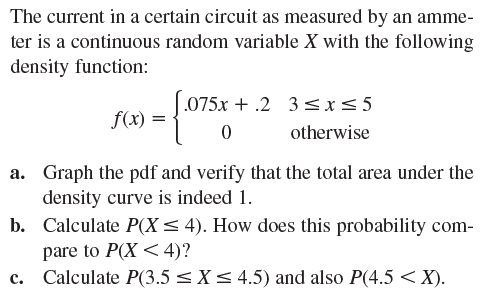

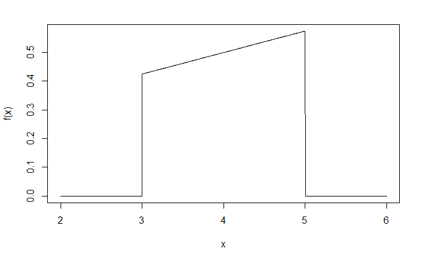

```r
f <- function(x){
  f <- .075 * x + .2
  f[(x< 3) | (x >5)] = 0
  return(f)
}
curve(f, 2, 6, n=1000)
```

```r
curve_area <- ( f(5) + f(3) )
cat("area under the curve should add to one. f(5) plus f(3) is: \n")
```

```
area under the curve should add to one. f(5) plus f(3) is:
```

```r
cat(curve_area)
```

```
1
```

```r
install.packages('pracma')
```

```
Error in install.packages : Updating loaded packages
```

```r
library(pracma)
cat("Compare P(X < 4) with P( X <= 4 )\n")
```

```
Compare P(X < 4) with P( X <= 4 )
```

```r
cat("P(X <= 4): ")
```

```
P(X <= 4):
```

```r
#cat(.075/2*16+.2*4-.075/2*9-.2*3)
integral(f,0,4)
```

```
[1] 0.4625
```

```r
cat("\nBoth are equal because in continuous distribution probability on any point is zero.")
```

```
Both are equal because in continuous distribution probability on any point is zero.
```

```r
cat("P(3.5 <= X <= 4.5): ")
```

```
P(3.5 <= X <= 4.5):
```

```r
#cat(.075/2*(4.5^2)+.2*4.5-.075/2*(3.5^2)-.2*3.5)
integral(f,3.5,4.5)
```

```
[1] 0.5
```

```r
cat("P(4.5 < X): ")
```

```
P(4.5 < X):
```

```r
#cat(.075/2*(5^2)+.2*5-.075/2*(4.5^2)-.2*4.5)
integral(f,4.5,5)
```

```
[1] 0.278125
```

#### Problem 2

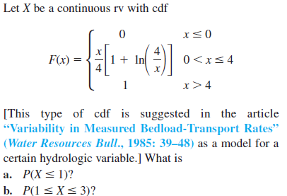

```r
e <- exp(1)
q <- function(x){
  q <- (x/4)+log(4/x, base = e)*x/4
  q[(x< 0)] = 0
  q[(x >4)] = 1
  return(q)
}
cat("What is P(X<1): ")
```

```
What is P(X<1):
```

```r
#integral(q,0,1)
variable1 <- 1/4+log(4/1)*1/4
cat(variable1)
```

```
0.5965736
```

```r
cat("\n What is P(1<=X<=3): ")
```

```
 What is P(1<=X<=3):
```

```r
#integral(q,1,3)
cat(3/4+log(4/3)*3/4 - variable1)
```

```
0.369188
```

#### Problem 3

Assume that an adult female is randomly selected. Females have pulse rates that are normally distributed with a mean of 74.0 beats per minute and a standard deviation of 12.5 beats per minute (based on Data Set 1 “Body Data” in Appendix B).

- Find the probability of a pulse rate less than 100 beats per minute.

```r
lessthan_100 <- pnorm(100,74,12.5)
cat("the probability of a pulse rate less than 100 beats per minute: \n")
```

```
the probability of a pulse rate less than 100 beats per minute:
```

```r
cat(lessthan_100)
```

```
0.9812372
```

- Find the probability of a pulse rate greater than 80 beats per minute.

```r
greaterthan_80 <- 1-pnorm(80,74,12.5)
cat("the probability of a pulse rate greater than 80 beats per minute: \n")
```

```
the probability of a pulse rate greater than 80 beats per minute:
```

```r
cat(greaterthan_80)
```

```
0.3156137
```

- Find the probability of a pulse rate between 60 beats per minute and 70 beats per minute.

```r
between60_70 <- pnorm(70,74,12.5) - pnorm(60,74,12.5)
cat("Pulse rate between 60 and 70 beats per minute: \n")
```

```
Pulse rate between 60 and 70 beats per minute:
```

```r
cat(between60_70)
```

```
0.2431273
```

- Find the probability of a pulse rate between 70 beats per minute and 90 beats per minute.

```r
between70_90 <- pnorm(90,74,12.5) - pnorm(70,74,12.5)
cat("Pulse rate between 70 and 90 beats per minute: \n")
```

```
Pulse rate between 70 and 90 beats per minute:
```

```r
cat(between70_90)
```

```
0.5252433
```

- Find $P_{90},$ which is the pulse rate separating the bottom 90% from the top 10%.

```r
p90 <- 1.28*12.5+74
cat("P90 is: ")
```

```
P90 is:
```

```r
cat(p90)
```

```
90
```

- Find the first quartile Q1, which is the pulse rate separating the bottom 25% from the top 75%.

```r
cat("The first quartile seperating the pulse rate is: \n")
```

```
The first quartile seperating the pulse rate is:
```

```r
qnorm(.25,74,12.5)
```

```
[1] 65.56888
```

#### Problem 4

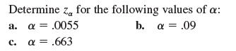

```r
cat("a: ")
```

```
a:
```

```r
qnorm(.0055,sd=1,mean=0)
```

```
[1] -2.542699
```

```r
cat("\nb: ")
```

```
b:
```

```r
qnorm(.09,mean=0,sd=1)
```

```
[1] -1.340755
```

```r
cat("\nc: ")
```

```
c:
```

```r
qnorm(.663,sd=1,mean=0)
```

```
[1] 0.4206646
```